# DATA 624: PREDICTIVE ANALYTICS HW2

Gabriel Campos

Last edited February 10, 2024

```r
library('fpp3')
library('tsibble')
library('ggplot2')
library('readr')
library('zoo')
library('cowplot')
library('ggfortify')
library('gridExtra')
library('latex2exp')
library('seasonal')
```

# Instuctions

Do exercises 3.1, 3.2, 3.3, 3.4, 3.5, 3.7, 3.8 and 3.9 from the online Hyndman book. Please include your Rpubs link along with.pdf file of your run code

# 3.1

## i

Consider the GDP information in `global_economy`. Plot the GDP per capita for each country over time. Which country has the highest GDP per capita?

```r
# global_economy
```

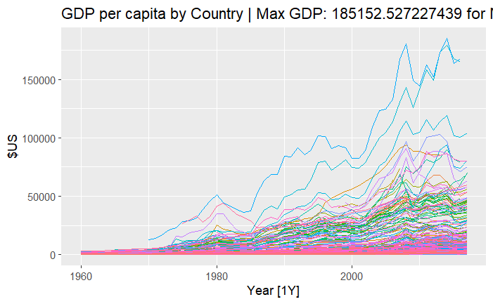

```r
# add GDP to the Data frame
global_economy <- global_economy %>%
  mutate(GDP_per_capita = GDP / Population)

# get the max values entire row for the title
max_gdp_row <- global_economy[which.max(global_economy$GDP_per_capita), ]


global_economy %>%
  autoplot(GDP_per_capita, show.legend = FALSE) +
  labs(title = paste("GDP per capita by Country | Max GDP:", max_gdp_row$GDP_per_capita, "for", max_gdp_row$Country, " in ",max_gdp_row$Year),
       y = "$US")
```

```r
NA
NA
```

```r
na_cnt<-sum(is.na(global_economy%>%
        filter(Country=="Monaco")%>%
          select(GDP_per_capita)))
paste("In the date range of 1960 to 2017 Monaco has had ",na_cnt," NA's")
```

```
[1] "In the date range of 1960 to 2017 Monaco has had  11  NA's"
```

## ii

How has this changed over time?

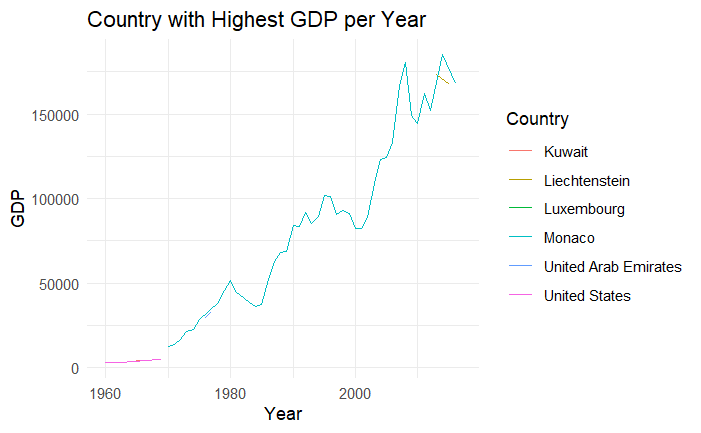

```r
global_economy <- index_by(global_economy, Year)

# store only rows with max gdp
max_gdp_annual <- global_economy %>%
  slice_max(GDP_per_capita) %>%
  ungroup()

# plot by rows selected
ggplot(max_gdp_annual, aes(x = Year, y = GDP_per_capita, color = Country)) +
  geom_line() +
  labs(title = "Country with Highest GDP per Year",
       x = "Year",
       y = "GDP") +
  theme_minimal()
```

# 3.2

For each of the following series, make a graph of the data. If transforming seems appropriate, do so and describe the effect.

# i

United States `GDP from global_economy`.

Using GDP per Capita made the most sense. It was already transformed by the above manipulations.

```r
fig1<-global_economy%>%
  filter(Country=="United States")%>%
    autoplot()+
  labs(title = "GDP US")
```

```
Plot variable not specified, automatically selected `.vars = GDP``mutate_if()` ignored the following grouping variables:
```

```r
fig2<-global_economy%>%
  filter(Country=="United States")%>%
    autoplot(GDP_per_capita)+
  labs(title = "GDP per Capita US")
```

```
`mutate_if()` ignored the following grouping variables:
```

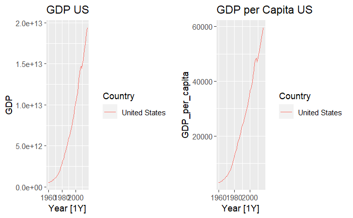

```r
plot_grid(fig1,
          fig2, nrow = 1)
```

# ii

Slaughter of Victorian “Bulls, bullocks and steers” in `aus_livestock`.

The data seemed clutter. By grouping it by Quarter the visual is clearer and the initial dip is apparent.

```r
head(aus_livestock)
```

| Month | Animal | State | Count |
| --- | --- | --- | --- |
| 1976 Jul | Bulls, bullocks and steers | Australian Capital Territory | 2300 |
| 1976 Aug | Bulls, bullocks and steers | Australian Capital Territory | 2100 |
| 1976 Sep | Bulls, bullocks and steers | Australian Capital Territory | 2100 |
| 1976 Oct | Bulls, bullocks and steers | Australian Capital Territory | 1900 |
| 1976 Nov | Bulls, bullocks and steers | Australian Capital Territory | 2100 |
| 1976 Dec | Bulls, bullocks and steers | Australian Capital Territory | 1800 |

```r
fig3 <- aus_livestock %>%
  filter(Animal == "Bulls, bullocks and steers") %>%
  summarise(Count = sum(Count)) %>%
  autoplot(show.legend=FALSE)
```

```
Plot variable not specified, automatically selected `.vars = Count`
```

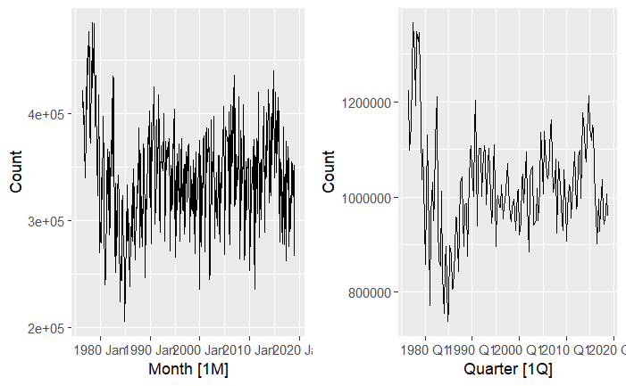

```r
fig4 <- aus_livestock %>%
  filter(Animal == "Bulls, bullocks and steers") %>%
  mutate(Quarter = yearquarter(Month)) %>%
  index_by(Quarter) %>%
  summarise(Count = sum(Count)) %>%
  autoplot(Count, show.legend=FALSE)

plot_grid(fig3, fig4, nrow = 1)
```

# iii

Victorian Electricity Demand from `vic_elec`.

```r
head(vic_elec)
```

| Time | Demand | Temperature | Date | Holiday |
| --- | --- | --- | --- | --- |
| 2012-01-01 00:00:00 | 4382.825 | 21.40 | 2012-01-01 | TRUE |
| 2012-01-01 00:30:00 | 4263.366 | 21.05 | 2012-01-01 | TRUE |
| 2012-01-01 01:00:00 | 4048.966 | 20.70 | 2012-01-01 | TRUE |
| 2012-01-01 01:30:00 | 3877.563 | 20.55 | 2012-01-01 | TRUE |
| 2012-01-01 02:00:00 | 4036.230 | 20.40 | 2012-01-01 | TRUE |
| 2012-01-01 02:30:00 | 3865.597 | 20.25 | 2012-01-01 | TRUE |

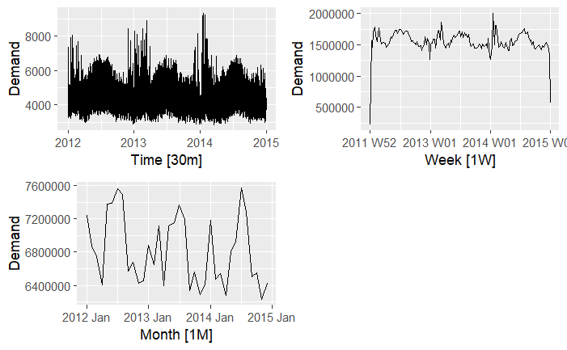

```r
fig5<-vic_elec%>%
        autoplot(Demand)

fig6<-vic_elec%>%
  mutate(Week = yearweek(Time)) %>%
  index_by(Week) %>%
  summarise(Demand = sum(Demand)) %>%
  autoplot(Demand, show.legend=FALSE)

fig7<-vic_elec%>%
  mutate(Month = yearmonth(Time)) %>%
  index_by(Month) %>%
  summarise(Demand = sum(Demand)) %>%
  autoplot(Demand, show.legend=FALSE)

# fig7<-vic_elec%>%
#   mutate(Day = as.Date(Time)) %>%
#   group_by(Day) %>%
#   summarise(Demand = sum(Demand)) %>%
#   autoplot(Demand, show.legend=FALSE)

plot_grid(fig5,
          fig6,
          fig7, nrow = 2)
```